# UKBioBank data exploration

Nitay Alon

December 16, 2018

In this report we explore the Human Brain Data from UK-Bio Bank as a preliminary step of applying our mixture of sexes model and hypothesis testing. We begin with extraction of relevant data for our research, as described in the 15/11/2018 meeting summary. we the proceed to visual inspection of relevant demographic data and begin analysis.

# EDA

## Kolmogorov Smirnov test

Next we apply K-S test for each column to determine if the data is Normally or Log-Normally distributed. We begin with testing for normal distribution.

```r
ks_results_log_normal_data <- applyKSTestForDataFrame(relevant_data,"L")
ks_results_normal_data <- applyKSTestForDataFrame(relevant_data,"N")
```

Now, we can compute the number of features for which the KS test wasn’t rejected:

```r
table(ks_results_log_normal_data$P_Value > 0.05)
```

```
##
## FALSE  TRUE
##   198    82
```

```r
table(ks_results_normal_data$P_Value > 0.05)
```

```
##
## FALSE  TRUE
##   244    36
```

the results above indicate that indeed the log-normal model is more likely than the normal model,however this is only a preliminary testing. Moreover, the testing above assumes a single distribution model, while we assume mixture model,thus it might be beneficial to split the data according to the sex and apply KS test per gender data.

## Validating the log-normal transformations

To validate the log transformation we examine if the third and froth moment of the logged data follow the expected behavior of the moments of normal distribution -
$$E(X^3) = 0 \\
E(X^4) = 3$$

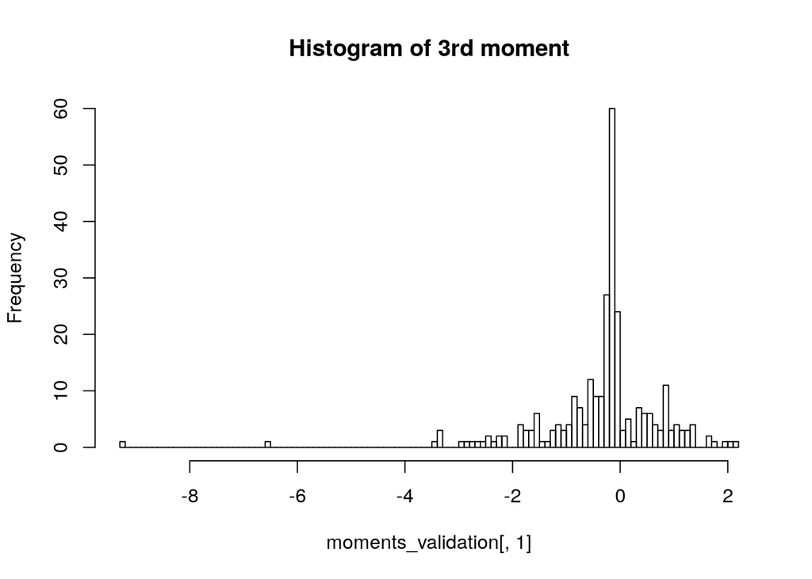

```r
data_for_log_and_scaled <- sapply(relevant_data, prepareDataForLogTransformation)
data_for_log_and_scaled %<>% data.frame()
logged_and_scaled <- sapply(data_for_log_and_scaled, function(x)
  {
  scale(log(x))
  })
logged_and_scaled %<>% data.frame()
moments_validation <- sapply(logged_and_scaled, validateMoments)
moments_validation %<>% t()
hist(moments_validation[,1],breaks = 100, main = "Histogram of 3rd moment")
```

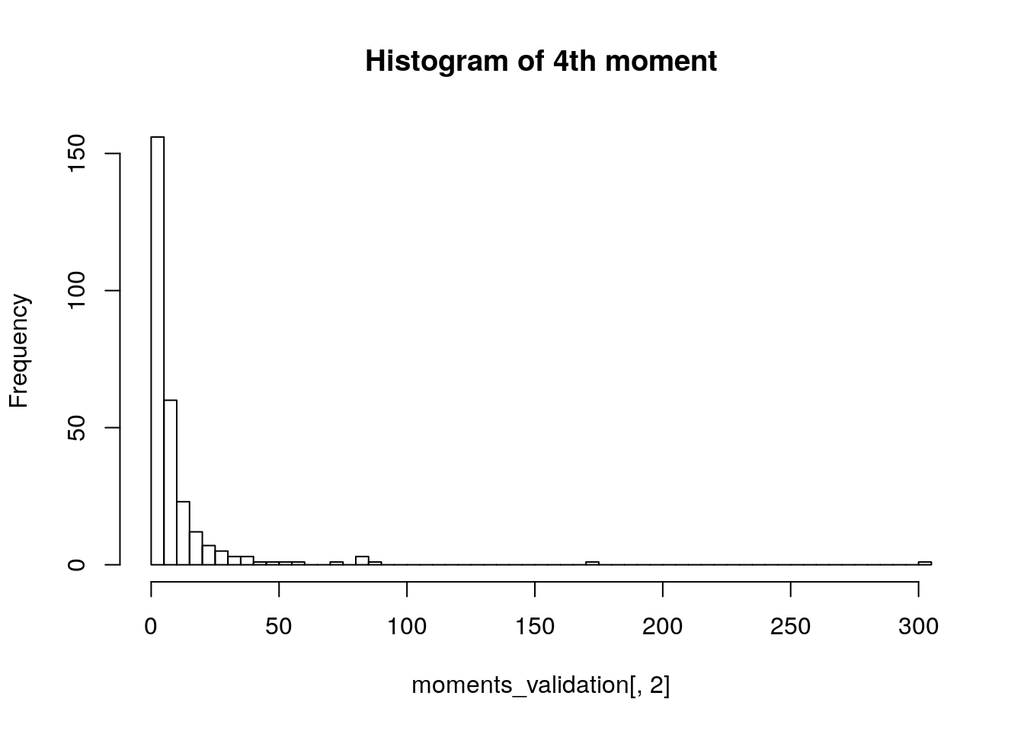

```r
hist(moments_validation[,2],breaks = 100, main = "Histogram of 4th moment")
```

Here we can see that some features do not follow the log-normal assumption. We can drill down and see some examples of features that violates our model:

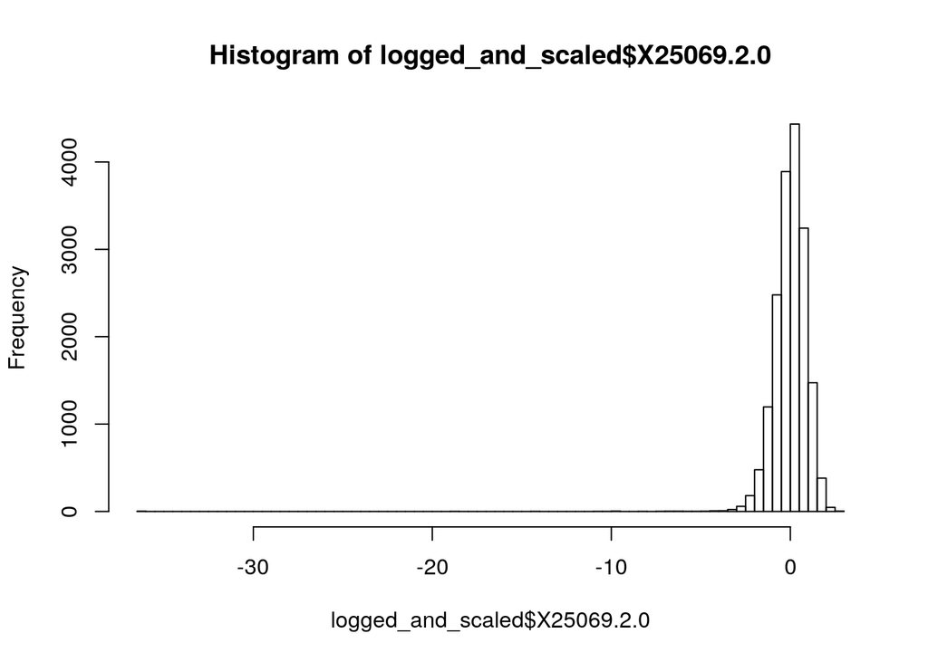

```r
extreme_feature_name_fourth_moment <- names(which.max(moments_validation[,2]))
extreme_feature_name_third_moment <- names(which.max(moments_validation[,1]))

hist(logged_and_scaled$X25069.2.0, breaks = 100)
```

```r
summary(logged_and_scaled$X25069.2.0)
```

```
##    Min. 1st Qu.  Median    Mean 3rd Qu.    Max.    NA's
## -36.191  -0.495   0.068   0.000   0.586   2.853    6009
```

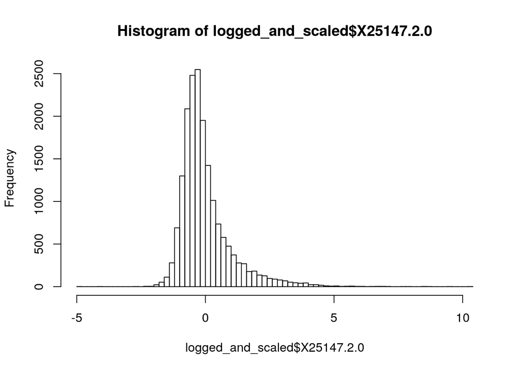

```r
hist(logged_and_scaled$X25147.2.0, breaks = 100)
```

```r
summary(logged_and_scaled$X25147.2.0)
```

```
##    Min. 1st Qu.  Median    Mean 3rd Qu.    Max.    NA's
##  -4.853  -0.603  -0.243   0.000   0.287  10.257    6009
```

here we see that in the first case the problem can be addressed by outlier removal but in the second case it is not the case.

### Deeper dive to skewed distribution analysis

```r
head(rownames(moments_validation)[order(moments_validation[,2],decreasing = T)],5)
```

```
## [1] "X25069.2.0" "X25068.2.0" "X25075.2.0" "X25077.2.0" "X25122.2.0"
```

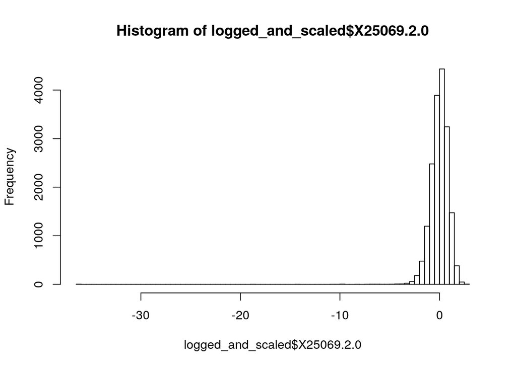

```r
hist(logged_and_scaled$X25069.2.0, breaks = 100)
```

```r
summary(logged_and_scaled$X25069.2.0)
```

```
##    Min. 1st Qu.  Median    Mean 3rd Qu.    Max.    NA's
## -36.191  -0.495   0.068   0.000   0.586   2.853    6009
```

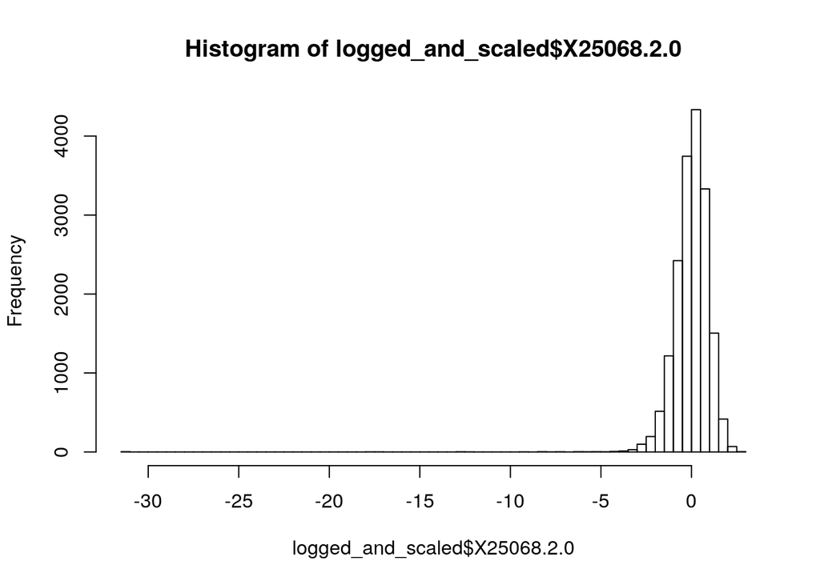

```r
hist(logged_and_scaled$X25068.2.0, breaks = 100)
```

```r
summary(logged_and_scaled$X25068.2.0)
```

```
##    Min. 1st Qu.  Median    Mean 3rd Qu.    Max.    NA's
## -31.029  -0.506   0.080   0.000   0.610   2.703    6009
```

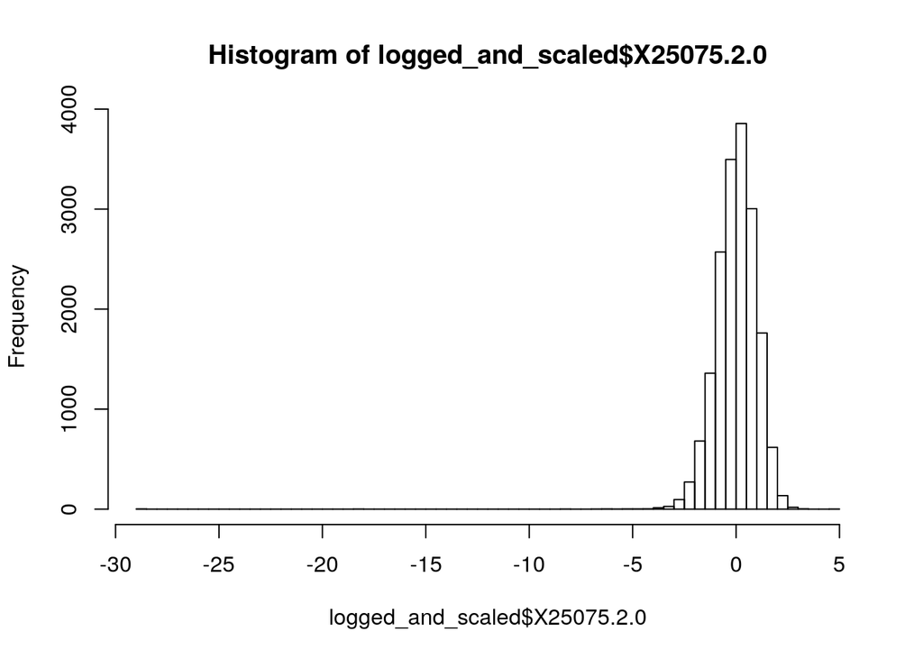

```r
hist(logged_and_scaled$X25075.2.0, breaks = 100)
```

```r
summary(logged_and_scaled$X25075.2.0)
```

```
##    Min. 1st Qu.  Median    Mean 3rd Qu.    Max.    NA's
## -28.879  -0.593   0.059   0.000   0.655   4.799    6009
```

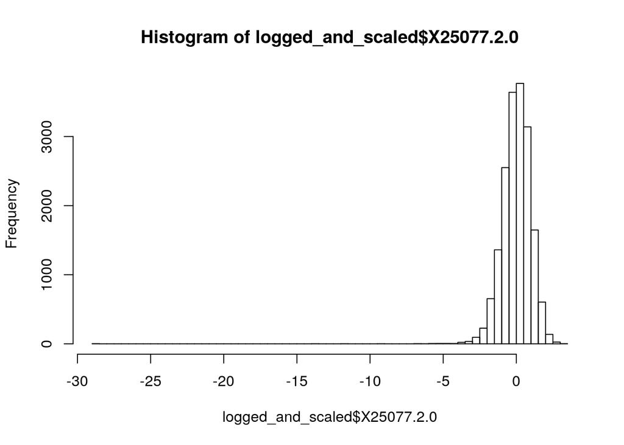

```r
hist(logged_and_scaled$X25077.2.0, breaks = 100)
```

```r
summary(logged_and_scaled$X25077.2.0)
```

```
##    Min. 1st Qu.  Median    Mean 3rd Qu.    Max.    NA's
## -28.921  -0.576   0.045   0.000   0.649   3.397    6009
```

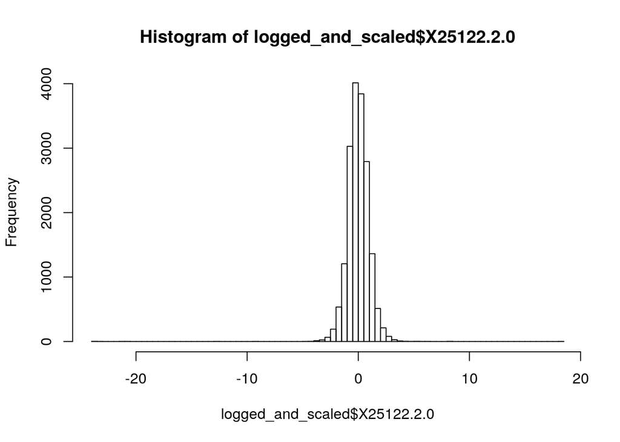

```r
hist(logged_and_scaled$X25122.2.0, breaks = 100)
```

```r
summary(logged_and_scaled$X25122.2.0)
```

```
##    Min. 1st Qu.  Median    Mean 3rd Qu.    Max.    NA's
## -23.567  -0.548  -0.016   0.000   0.550  18.424    6009
```

And it seems that those distributions are indeed centered, but they have one or two outliers.

```r
head(rownames(moments_validation)[order(moments_validation[,1],decreasing = T)],5)
```

```
## [1] "X25147.2.0" "X25146.2.0" "X25115.2.0" "X25131.2.0" "X25130.2.0"
```

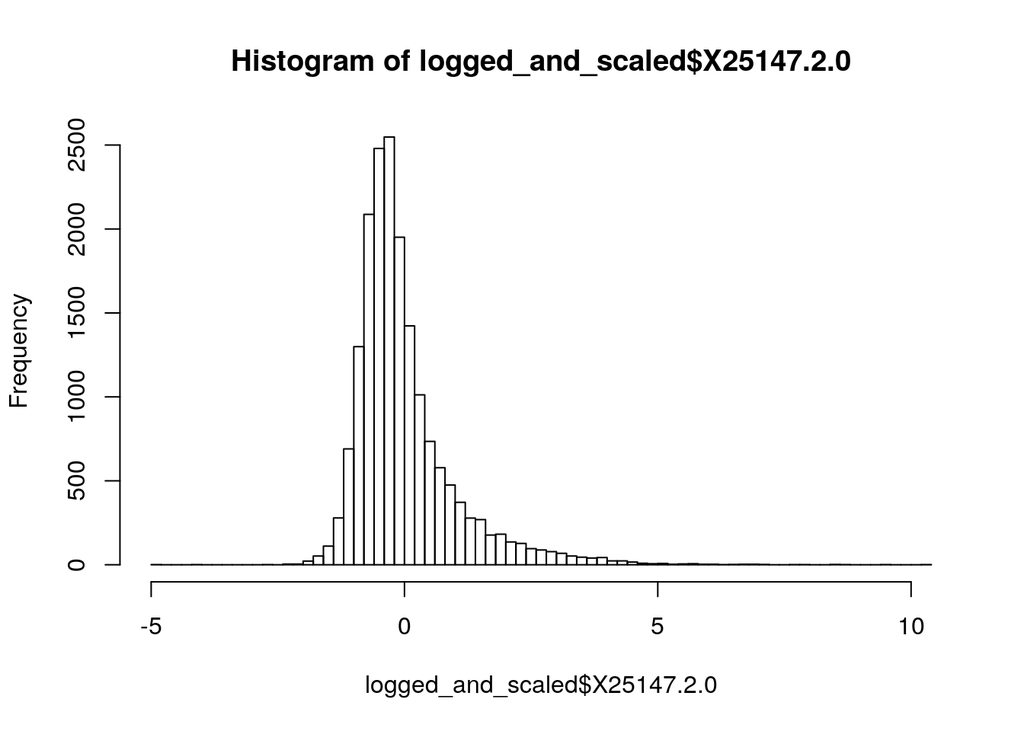

```r
hist(logged_and_scaled$X25147.2.0, breaks = 100)
```

```r
summary(logged_and_scaled$X25147.2.0)
```

```
##    Min. 1st Qu.  Median    Mean 3rd Qu.    Max.    NA's
##  -4.853  -0.603  -0.243   0.000   0.287  10.257    6009
```

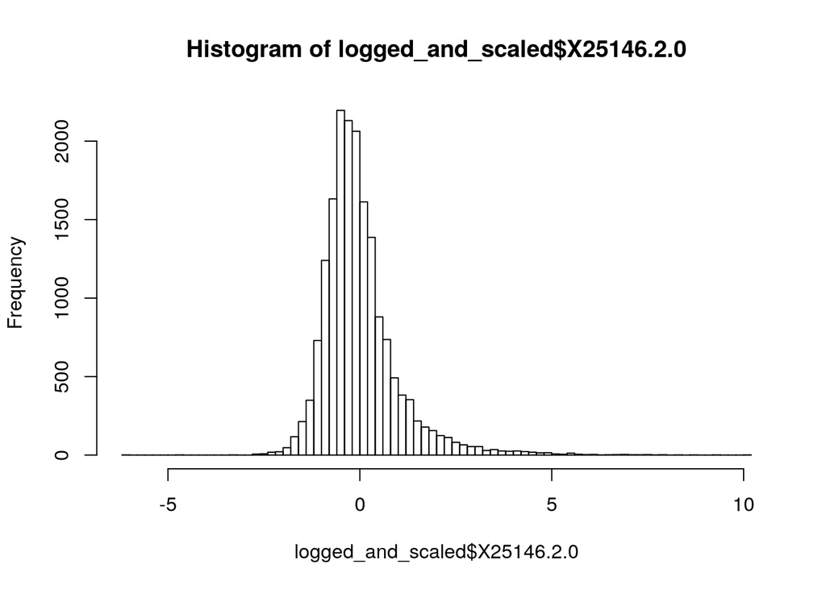

```r
hist(logged_and_scaled$X25146.2.0, breaks = 100)
```

```r
summary(logged_and_scaled$X25146.2.0)
```

```
##    Min. 1st Qu.  Median    Mean 3rd Qu.    Max.    NA's
##  -6.129  -0.591  -0.180   0.000   0.347  10.033    6009
```

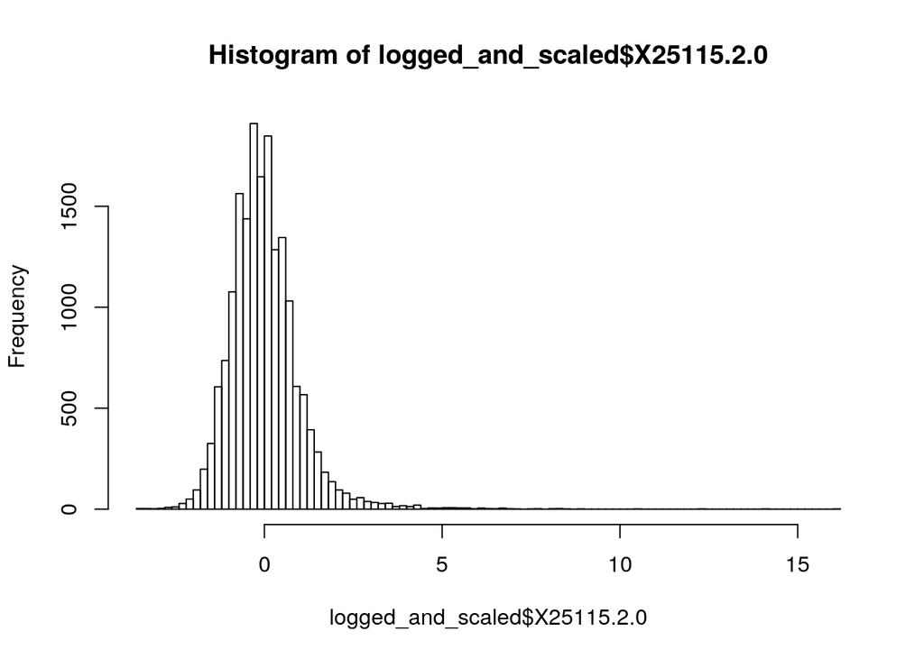

```r
hist(logged_and_scaled$X25115.2.0, breaks = 100)
```

```r
summary(logged_and_scaled$X25115.2.0)
```

```
##    Min. 1st Qu.  Median    Mean 3rd Qu.    Max.    NA's
##  -3.575  -0.611  -0.099   0.000   0.474  16.043    6009
```

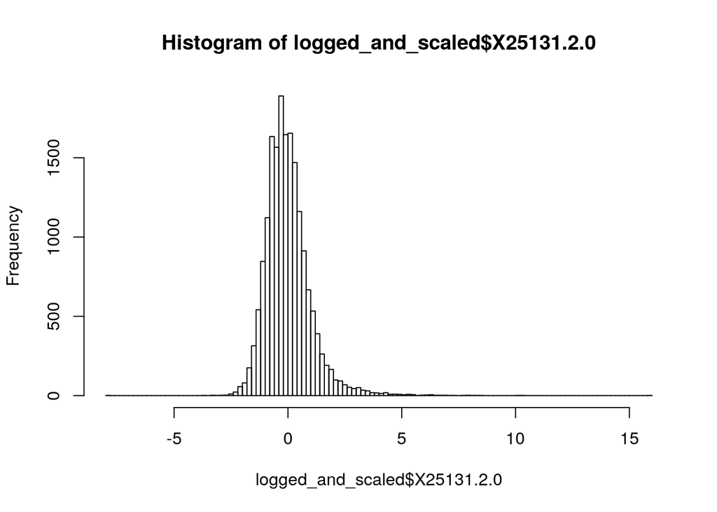

```r
hist(logged_and_scaled$X25131.2.0, breaks = 100)
```

```r
summary(logged_and_scaled$X25131.2.0)
```

```
##    Min. 1st Qu.  Median    Mean 3rd Qu.    Max.    NA's
##  -7.887  -0.626  -0.120   0.000   0.470  15.943    6009
```

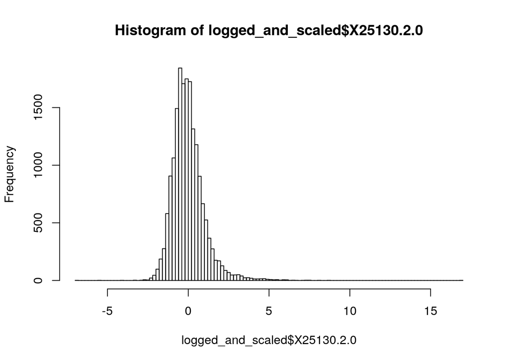

```r
hist(logged_and_scaled$X25130.2.0, breaks = 100)
```

```r
summary(logged_and_scaled$X25130.2.0)
```

```
##    Min. 1st Qu.  Median    Mean 3rd Qu.    Max.    NA's
##  -7.000  -0.638  -0.110   0.000   0.457  16.922    6009
```

## Composite vs simple hypothesis testing

First we test the single distribution vs composite distribution hypotheses:
$$H_0:f_X(x) = f_X(x) \\
H_1:f_X(x) = pf_X(x) + (1-p)g_X(x)$$

One feature breaks the EM method:

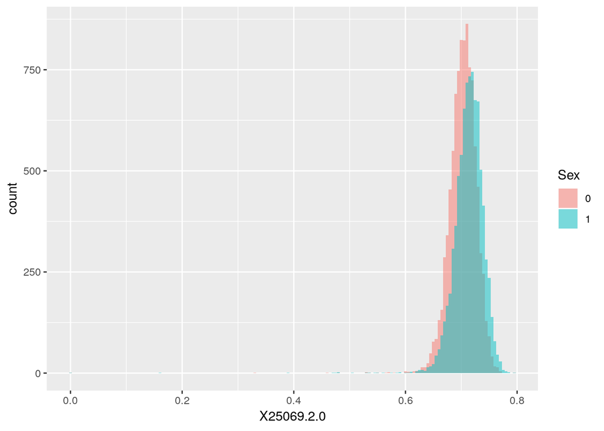

```r
df <- data.frame("X25069.2.0" = full_relevant_data$X25069.2.0,
                 "Sex" = full_relevant_data$Sex)
bioBankHistogramBySex(df, "X25069.2.0")
```

Here we see that the extreme observations in the men data cause the EM to explode. This particular feature worth separate investigation.

### Summarizng the first hypothesis test

In order to decide for which features we reject the null hypothesis we compare the $llrt$ with the critical value of the proper $\chi^2$ statistic. Using Wald’s theorem we know that under the null hypothesis the llrt is distributed $\chi^2$ with $5-2$ df (We have 2 parameters in the null hypothesis and 5 in the alternative). After FDR correction we use the 99% percentile of this distribution:

```r
critical_value <- qchisq(0.99,3)
hypothesis_result %<>% as.data.frame()
names(hypothesis_result) <- c("llrt")
hypothesis_result$reject_the_null_hypothesis <-
  hypothesis_result$llrt > critical_value
hypothesis_result$reject_the_null_hypothesis %>%
  table() %>%
  prop.table()
```

```
## .
##      FALSE       TRUE
## 0.06785714 0.93214286
```

And we can see that $93\%$ of the features are assumed to be a mixture model and not pure, single distribution.

# Mixture model - pure type vs Mixture of Mixtures

Our main focus is on testing our mixture of mixture model, to test these hypotheses we apply the composite hypothesis log-likelihood ratio test.

## Log normal assumption

We start with assuming log-normal model

Now, We plot the llrt results:

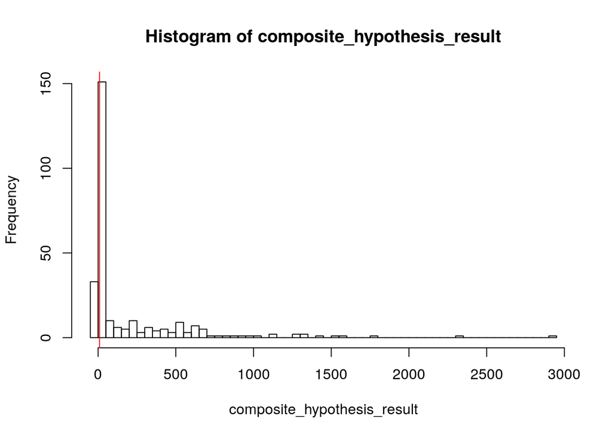

```r
hist(composite_hypothesis_result, breaks = 50)
abline(v = qexp(0.99,0.5), col = "red")
```

(red line indicating the $99\%$ percentile of $exp(\frac{1}{2})$).

### Analyzing low llrt

We see that some features have llrt less than 1 - let’s review them separately.

First we notice that one feature has Nan llrt:

```r
X25069.2.0 <- na.omit(relevant_data$X25069.2.0)
X25069.2.0 %>% prepareDataForLogTransformation() %>% log() %>% summary()
```

```
##    Min. 1st Qu.  Median    Mean 3rd Qu.    Max.
## -1.8210 -0.3666 -0.3437 -0.3464 -0.3225 -0.2302
```

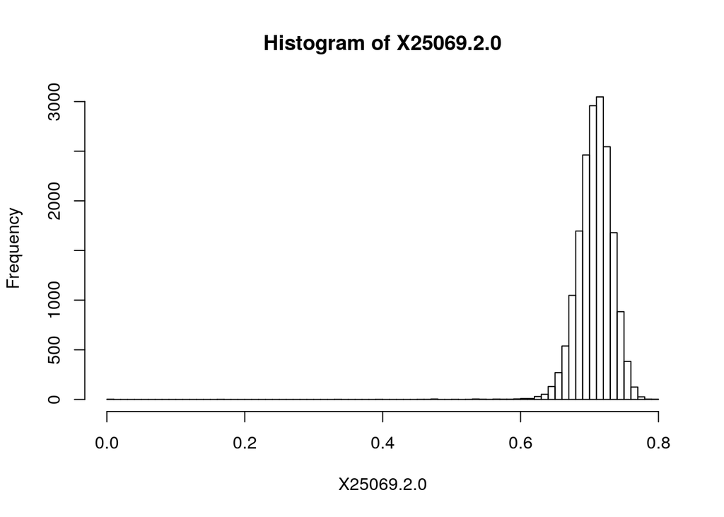

```r
hist(X25069.2.0, breaks = 100)
```

by looking at the histogram we see that most of the data is centered at 0.7 but there’s a left tail:

```r
summary(X25069.2.0)
```

```
##    Min. 1st Qu.  Median    Mean 3rd Qu.    Max.
##  0.0000  0.6931  0.7092  0.7077  0.7243  0.7944
```

```r
head(sort(X25069.2.0,decreasing = F),5)
```

```
## [1] 0.000000 0.000000 0.161862 0.330719 0.392399
```

```r
quantile(X25069.2.0,c(0,0.01,0.05))
```

```
##        0%        1%        5%
## 0.0000000 0.6446374 0.6677683
```

```r
gender_data_for_X25069.2.0 <-
  full_relevant_data$Sex[!is.na(relevant_data$X25069.2.0)]

full_em_for_X25069.2.0 <- pureTypeMixtureVsCompositeMixture(X25069.2.0[X25069.2.0>0],
                                  gender_data = gender_data_for_X25069.2.0,"L",return_full_data = T)
```

Plotting the distribution:

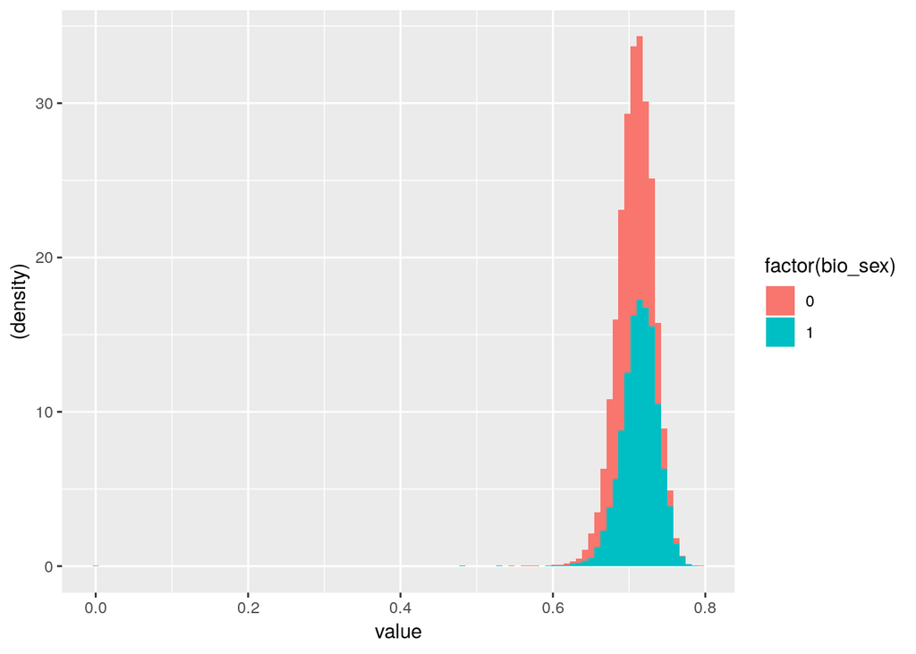

```r
data_for_ggplot_X25069.2.0 = data.frame(value = X25069.2.0,
                                        bio_sex = gender_data_for_X25069.2.0)

ggplot(data_for_ggplot_X25069.2.0, aes(value, fill = factor(bio_sex))) +
  geom_histogram(bins = 100, aes(y = (..density..)))
```

and this model seems more like the “normal and extreme population model”.

Selecting the smallest value:

Plotting the distribution:

```r
X25826.2.0 <- na.omit(relevant_data$X25826.2.0)
X25826.2.0 %>%
  prepareDataForLogTransformation() %>%
  log() %>%
  summary()
```

```
##    Min. 1st Qu.  Median    Mean 3rd Qu.    Max.
##   8.102   8.766   8.878   8.874   8.988   9.561
```

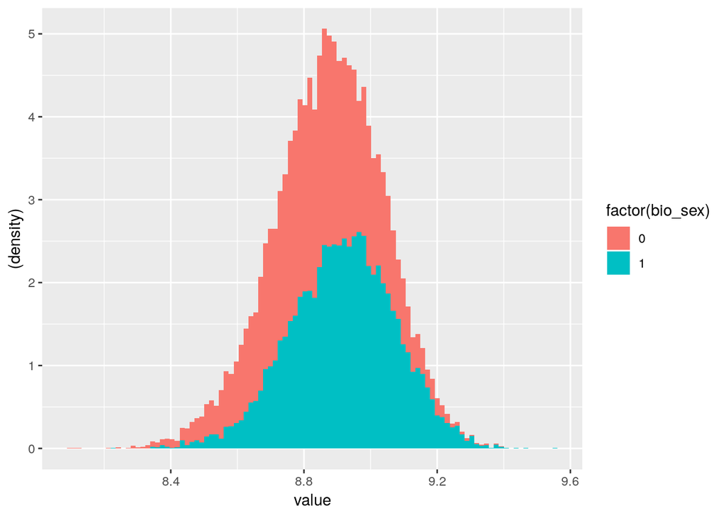

```r
gender_data_for_X25826.2.0 <-
  full_relevant_data$Sex[!is.na(relevant_data$X25826.2.0)]

data_for_ggplot_X25826.2.0 = data.frame(value = X25826.2.0 %>%
  prepareDataForLogTransformation() %>%
  log(),
                                        bio_sex = gender_data_for_X25826.2.0)

ggplot(data_for_ggplot_X25826.2.0, aes(value, fill = factor(bio_sex))) +
  geom_histogram(bins = 100, aes(y = (..density..)))
```

And we can see a clear single distribution.

### Analysis of composite hypothesis testing:

In order to determine the number of significant features we use Wald’s theorem again this time with $\chi^2_2$ distribution.

```r
critical_value <- qexp(0.99,1/2)
composite_hypothesis_result %<>% as.data.frame()
names(composite_hypothesis_result) <- c("llrt")
composite_hypothesis_result$reject_the_null_hypothesis <-
  composite_hypothesis_result$llrt > critical_value
composite_hypothesis_result$reject_the_null_hypothesis %>%
  table() %>%
  prop.table()
```

```
## .
##    FALSE     TRUE
## 0.483871 0.516129
```

So, for the small majority of the features we reject the null hypothesis. Next we repeat the analysis assuming normal distribution.

# Normal distribution assumption analysis

Next we repeat the analysis, but assuming normal distribution instead of log-normal.

## Simple vs composite

### Summarizng the simple vs composite hypothesis

As before, we use the same critical value to reject the null hypothesis.

```r
critical_value <- qchisq(0.99,3)
simple_hypothesis_result_normal_assumption %<>% as.data.frame()
names(simple_hypothesis_result_normal_assumption) <- c("llrt")
simple_hypothesis_result_normal_assumption$reject_the_null_hypothesis <-
  simple_hypothesis_result_normal_assumption$llrt > critical_value
simple_hypothesis_result_normal_assumption$reject_the_null_hypothesis %>%
  table() %>%
  prop.table()
```

```
## .
##     FALSE      TRUE
## 0.1071429 0.8928571
```

And we can see that almost $90\%$ of the features are assumed to be a mixture model and not pure, single distribution.

## Pure type mixture model vs mixture of mixture

As before, we now test the hypotheses that the data was generated by a mixture model of 2 pure types (null) vs the alternative, that the data is generated by a mixture of mixtures.

using EM we can compute the llrt: Now we apply the composite hypothesis log-likelihood ratio test:

As before, we begin with visual inquiry: Now, We plot the llrt results:

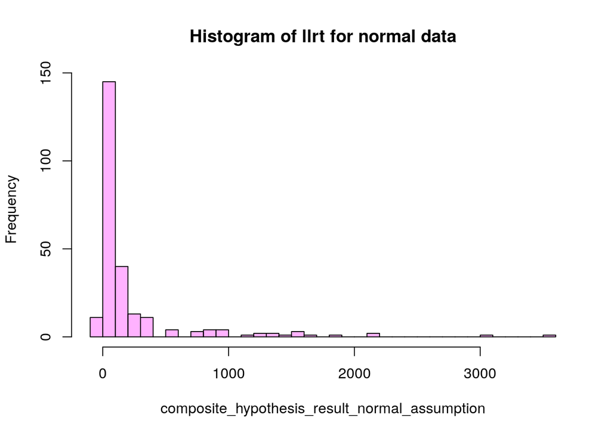

```r
hist(composite_hypothesis_result_normal_assumption,
     col = rgb(1,0,1,alpha = 0.3), breaks = 50,
     main = "Histogram of llrt for normal data")
```

And we can compare the performance of the log-normal assumption vs the normal assumption:

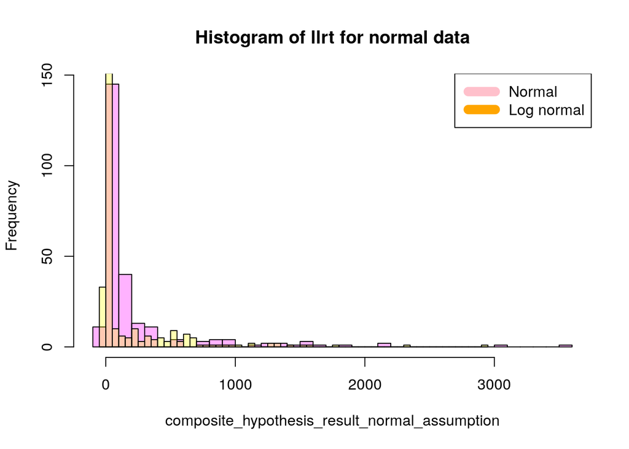

```r
hist(composite_hypothesis_result_normal_assumption,
     col = rgb(1,0,1,alpha = 0.3), breaks = 50,
     main = "Histogram of llrt for normal data")
hist(composite_hypothesis_result[,1],
     col = rgb(1,1,0,alpha = 0.3),
     breaks = 50, add = T)
legend("topright", c("Normal", "Log normal"),
       col=c("Pink", "Orange"), lwd=10)
```

Analysis of llrt:

```r
critical_value <- qexp(0.99,1/2)
composite_hypothesis_result_normal_assumption %<>% as.data.frame()
names(composite_hypothesis_result_normal_assumption) <- c("llrt")
composite_hypothesis_result_normal_assumption$reject_the_null_hypothesis <-
  composite_hypothesis_result_normal_assumption$llrt > critical_value
composite_hypothesis_result_normal_assumption$reject_the_null_hypothesis %>%
  table() %>%
  prop.table()
```

```
## .
## FALSE  TRUE
##  0.32  0.68
```